# Week 8 - Introduction to R

### Objectives

By the end of this lab, you should be able to:

- Understand the basic syntax of the R programming language
- Run a simple statistical analysis using R (linear regression)

### Introduction

This week is the first lab we’ll do using the R programming language. So, we’ll spend a fair amount of time introducing R. If you already know R, you may be able to go quickly through most of this document. At the end of the lab, we’ll use R to fit a simple linear model to some data.

R is a programming language. It is widely used in statistics, so it has basic statistics functions built-in, and many advanced statistics libraries are written in it.

If you’re new to R, the best way to remember how to use it is to not just read - try typing in the below commands yourself, and experiment.

### Preparation

We’ll use RStudio, which is an interactive development environment for the R programming language. You can use RStudio on the teaching server that you logged in to in Week 1, by navigating to (using the server on which you have an account) one of:

- Username a-c: http://comp90014-a.genome.edu.au/rstudio
- Username d-k: http://comp90014-b.genome.edu.au/rstudio
- Username l-t: http://comp90014-c.genome.edu.au/rstudio
- Username u-z: http://comp90014-d.genome.edu.au/rstudio

Your username and password will be the same as for linux (and Jupyter). You can change your password from the linux command line, using the instructions in the Week 1 lab.

**Important: If you do any work on the teaching servers that you’d like to keep, you should download a backup copy of your work at the end of your session. You can download saved files from RStudio using the Files tab at the lower-right. Select any saved files you want, and use More->Export to download them.**

If want to use your own computer, you can (only if you want to) install R (http://cran.r-project.org/) and RStudio (http://www.rstudio.com/products/rstudio/download/) instead of using a server.

It’s worth realising that although we will use RStudio, it is not needed to use R - if you have R installed you can enter a (less sophisticated) interactive R environment from the command-line just by typing `R`. You can then leave this environment by typing `quit()`.

You can also run R scripts directly from the command-line with the `Rscript` command.

### RStudio

RStudio is an interactive environment for running R. Once you’ve logged into it, you should see:

- The Console (entire left)
- Workspace/History (tabbed in upper right)
- Files/Plots/Packages/Help (tabbed in lower right)

Your demonstrator will give a quick overview of these. Mostly you will work in the Console, where you can type in R code, run it immediately, and see the output. However you may also want to write and save an R script, which you can do from the File menu.

One useful thing to know how to do is to save your Console History as a file - i.e. save all the commands you’ve entered. You can see your history in the History tab in the upper right, and save it to a file with the Save icon. This saves to a file on the server where RStudio is running - you still need to download it if you want an offline copy.

### R fundamentals: variables and functions, getting help

If you’re new to programming, you will have seen variables and functions before in our Python workshop. These concepts apply to all programming languages, including R.

R has a special operator for assigning a value to a variable, which looks like <- (that’s two characters, < and - with no space in between them).

```r
x <- 5
print(x)
```

```
## [1] 5
```

You can also just use =, like this:

```r
# This does the same thing
x = 5
print(x)
```

```
## [1] 5
```

Just as in Python, strings have quotes around them:

```r
mystring = "This is a string"
print(mystring)
```

```
## [1] "This is a string"
```

and we can do maths:

```r
y <- 7 + x
print(y)
```

```
## [1] 12
```

Like most programming languages, R has functions. You can define your own functions, but most of the time in our workshops we will just use built-in R functions, or functions from statistics libraries. As usual, functions are called by putting their parameters in brackets, and they can return a value. Let’s try `sqrt()`, which is a built-in R function that calculates the square root.

```r
z = sqrt(5)
print(z)
```

```
## [1] 2.236068
```

One very useful feature of the interactive R environment is that you can get help with the `help()` function, or if you prefer, the `?` operator. Just type `?` followed by the function you want help for:

```r
# This gets documentation
help(sqrt)
# So does this
?sqrt
```

Another way to solve problems is the `str()` function. `str()` stands for *structure*, and is extremely useful for troubleshooting. It gives you information about a variable, such as the type, size and contents. When we start dealing with more complicated data types like lists or data frames, str() will become very useful.

```r
str(x)
```

```
##  num 5
```

Try it out: run str() on some of the other variables we created above.

### Libraries

R has libraries which provide lots of extra functions. These will be very important for us, since we’d like to use libraries designed for transcriptomics. Many libraries for bioinformatics in R can be found in the Bioconductor project (http://www.bioconductor.org/).

We are going to install the limma library, which has functions for differential gene expression analysis for both microarray and RNA-seq data. The usual way to install a library into R is with the `install.packages()` function. For Bioconductor packages there is a special method:

```r
source("http://bioconductor.org/biocLite.R")
biocLite("limma")
```

If you are asked if you wish to use a personal library, answer yes. This installs limma in your private version of RStudio.

Libraries can be loaded with the `library()` function.

```r
library("limma")
```

This loads limma. All the functions in the limma library will now work. We can also now get help on the limma library with

```r
?limma
```

which will tell us how to find more detailed documentation.

Try to also install the Bioconductor package edgeR now.

### Data structures in R

We won’t do a lot of complex programming in R, but we will use it for data analysis, so we need to understand how to manipulate data! We’ll go through the most important data types.

#### Vectors and Lists

Vectors and lists store collections of values. If you’re new to programming you have probably seen lists in Python - they looked like `[1,3,5]`. R’s vectors and lists are quite similar: ordered collections of items, assigned to a variable.

One way to make a vector is with the `c()` function, which means “concatenate”.

```r
odd.numbers <- c(1,3,5,7)
print(odd.numbers)
```

```
## [1] 1 3 5 7
```

By the way, you might notice there is a dot (`.`) in the variable name. This has no special meaning in R (unlike some other languages), it’s just part of the variable name.

Some more handy ways to make vectors of numbers:

```r
# Numbers from 1 to 10
all.numbers <- 1:10
print(all.numbers)
```

```
##  [1]  1  2  3  4  5  6  7  8  9 10
```

```r
# Numbers from 1 to 10, step size of two
odd.numbers <- seq(1,10,2)
print(odd.numbers)
```

```
## [1] 1 3 5 7 9
```

Vectors can be indexed and sliced (just like in Python!). However unlike Python, the first item is indexed with `1`, not `0`.

```r
# The first value
odd.numbers[1]
```

```
## [1] 1
```

```r
# The second value
odd.numbers[2]
```

```
## [1] 3
```

```r
# Second to fourth
odd.numbers[2:4]
```

```
## [1] 3 5 7
```

These atomic vectors are the most fundamental type in R. Even when you write `x <- 5`, you are actually making a vector of length 1, exactly as if you’d written `x <- c(5)`.

**Lists** in R are also ordered collections of items, but unlike vectors, they don’t all have to be of the same type:

```r
mylist <- list(1,"a string",5.3)
print(mylist)
```

```
## [[1]]
## [1] 1
##
## [[2]]
## [1] "a string"
##
## [[3]]
## [1] 5.3
```

We won’t go into these in detail, but data frames, which we’ll look at soon, are really just lists of vectors.

#### Matrices

A matrix in R is like a two-dimensional vector: a grid of numbers.

```r
# Make a matrix with two rows
nums <- c(1, 5, 1.5, 4.5, 3.5, 5.3, 3.1, 5.1)
X <- matrix(nums, nrow=2)
print(X)
```

```
##      [,1] [,2] [,3] [,4]
## [1,]    1  1.5  3.5  3.1
## [2,]    5  4.5  5.3  5.1
```

Matrices will be useful when we want to describe tables of gene expression values. Let’s assign names to the rows and columns to illustrate this:

```r
# Genes on rows, samples on columns
rownames(X) <- c("Gene 1", "Gene 2")
colnames(X) <- c("Untreated_1", "Untreated_2", "Treated_1", "Treated_2")
print(X)
```

```
##        Untreated_1 Untreated_2 Treated_1 Treated_2
## Gene 1           1         1.5       3.5       3.1
## Gene 2           5         4.5       5.3       5.1
```

We can index and slice a matrix using vectors of numbers.

```r
# First row, second column
X[1,2]
```

```
## [1] 1.5
```

```r
# Rows 1-2, columns 2-4
X[1:2,2:4]
```

```
##        Untreated_2 Treated_1 Treated_2
## Gene 1         1.5       3.5       3.1
## Gene 2         4.5       5.3       5.1
```

```r
# Leave out the column index to mean all columns
X[2,]
```

```
## Untreated_1 Untreated_2   Treated_1   Treated_2
##         5.0         4.5         5.3         5.1
```

We’ll use matrices to define the *design matrix* and *contrast matrix* when doing differential expression analyses.

#### Data Frames

Data frames are the last data type we’ll look at. They are one of the most important features of R, and are what we’ll almost always use for tabular data and for statistics. R has convenient functions for reading tables of values from text files and turning them into data frames.

You can think of a data frame like a spreadsheet: columns of values, where each column has a name and can be a different type of variable.

```r
# Use the data.frame() function to make a data frame
# Use three vectors made with c() as the columns
df <- data.frame(firstname=c("Simon", "Alex", "Ruby"), lastname=c("Smith", "Anders", "Anders"), height=c(182,162,174))
print(df)
```

```
##   firstname lastname height
## 1     Simon    Smith    182
## 2      Alex   Anders    162
## 3      Ruby   Anders    174
```

You can index the elements of a data frame like a matrix, like `df[1, 2:3]`. You can also refer to columns by name, like `df["height"]`, or using the `$` operator, like `df$height`:

```r
df$height
```

```
## [1] 182 162 174
```

```r
df$firstname[1]
```

```
## [1] Simon
## Levels: Alex Ruby Simon
```

One very common way to manipulate data is *boolean indexing*, which means we can get all the rows or columns of a data frame where some condition is true. For instance, to get all the rows where the surname is “Anders”:

```r
# The condition gives a vector of true/false values
df$lastname == "Anders"
```

```
## [1] FALSE  TRUE  TRUE
```

```r
# Indexing with the vector on rows gives just the rows where this is true
df[ df$lastname == "Anders", ]
```

```
##   firstname lastname height
## 2      Alex   Anders    162
## 3      Ruby   Anders    174
```

See if you can extract the names of people with heights more than 170cm.

Remember the `str()` function that tells us about a variable’s type and structure? Now that we’ve seen some more advanced data structures, `str()` will be much more useful. Try it out on data frames with `str(df)`, and on some of the other types we’ve seen.

### Vectorisation

You might have noticed that above, we applied `==` to a vector, and got back a vector of TRUE/FALSE values.

We haven’t talked about how to write a for loop in R. It’s possible, but for our data analysis we usually won’t need to! This is because R has **vectorised** nearly all its functions and operators: if you apply them to a vector they automatically work for the whole vector. So

```r
x <- 5
print(x+2)
```

```
## [1] 7
```

may not be surprising if you’re used to other programming languages, but

```r
v <- c(1,2,3,4,5)
print(v+2)
```

```
## [1] 3 4 5 6 7
```

might be.

This will work for other operators, like `**` (to the power of):

```r
v <- c(1,2,3,4,5)
print(v**3)
```

```
## [1]   1   8  27  64 125
```

And it will work for many functions:

```r
v <- c(1,2,3,4,5)
print(sqrt(v))
```

```
## [1] 1.000000 1.414214 1.732051 2.000000 2.236068
```

In R, using vectorised functions is usually much more efficient than using loops.

Questions: What do you think `v + v` will give?

If `a <- c(1,3,5,7)` and `b <- c(1,10)`, what will `a + b` give? This second question is tricky as R doesn’t do what you might think - try it out.

### Plots

R is particularly useful for drawing plots. The simplest way is the `plot()` function:

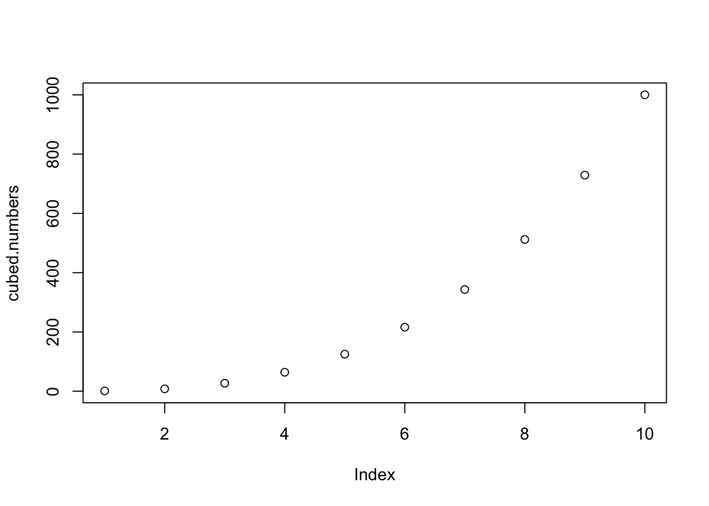

```r
numbers = 1:10
cubed.numbers = numbers**3
plot(cubed.numbers)
```

There are many advanced libraries and techniques for plotting in R, but it’s too big a topic to go through here. We will cover what we need as we need it. Remember that you can see documentation with `?plot`. There are a few other basic plotting functions, such as `hist()` (for histograms), and `boxplot()`.

If you draw a plot in RStudio, it will appear in the **Plots** tab in the lower-right pane.

### Regression Models

In linear regression, we want to fit a model to data. For instance, if we think our data should fit a model like
$$y = a x + b$$
then, given data points for $y$ and $x$, we’d like to use regression to find the coefficients $a$ and $b$.

R has a special data type and syntax for defining a formula, which we can then use as a model to fit to data. The `~` operator is used for this.

```r
model <- y ~ x
print(model)
```

```
## y ~ x
```

This means that we think `y` is a linear function of `x`. We don’t need to write the coefficients out explicitly: `y ~ x` is enough. If we give the `lm()` function this model, and some data for `x` and `y`, it will attempt to fit the model to the data.

We can pass our data in to `lm()` as a data frame, and the `y` and `x` will then refer to columns of the data frame.

Let’s illustrate with a realistic problem.

#### RNA-seq and GC content

One factor that can affect our experiments is the **GC content** of the DNA sequence. This simply means what percentage of the base pairs are G-C, as opposed to A-T. If the DNA were random, the GC content would on average be 50%, but in real DNA there are many factors which can affect GC content.

In DNA molecules, G binds to C much more strongly than A binds to T. This can affect our sequencing experiments.

In this experiment, RNA-seq counts for six different regions of the same gene were counted across multiple experiments to produce a total count for each region. We hypothesise that counts from this gene are influenced by GC content of the sequence and the length of the region examined.

More specifically, the model we will try to fit is

```r
log(counts) ~ log(sizes) + gc
```

Let’s look at some data.

```r
# Length of each region
sizes = c(489, 694, 813, 920, 1211, 2407)

# GC content of each region
gc = c(0.68, 0.54, 0.44, 0.43, 0.57, 0.58)

# RNA-seq counts obtained for each region
counts = c(37035, 46293, 39504, 44442, 74070, 177768)

# Put our three variables into a data frame
# Notice that R keeps their names as column names!
data = data.frame(counts, sizes, gc)
print(data)
```

```
##   counts sizes   gc
## 1  37035   489 0.68
## 2  46293   694 0.54
## 3  39504   813 0.44
## 4  44442   920 0.43
## 5  74070  1211 0.57
## 6 177768  2407 0.58
```

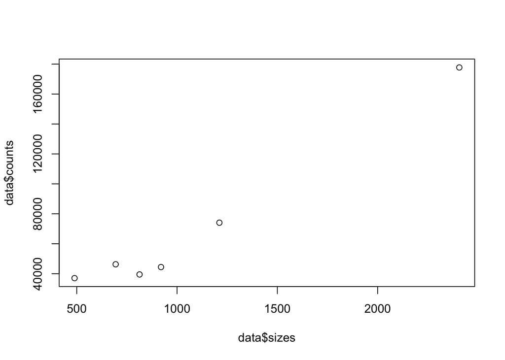

```r
# What does the data look like?
# Plot with two vectors will give plot(x,y)
plot(data$sizes, data$counts)
```

It looks plausible that `counts` does depend on `sizes`. Try for yourself to plot `counts` against `gc`.

Now we’ll fit the model to the data. The `lm()` function will return a data structure containing the results of the fit, including the coefficients.

```r
# Fit the model using lm()
fit = lm(log(counts) ~ log(sizes) + gc, data)

# Examine the resulting data structure
summary(fit)
```

```
##
## Call:
## lm(formula = log(counts) ~ log(sizes) + gc, data = data)
##
## Residuals:
##        1        2        3        4        5        6
## -0.02219  0.10587 -0.02212 -0.01695 -0.08153  0.03691
##
## Coefficients:
##             Estimate Std. Error t value Pr(>|t|)
## (Intercept)  2.53550    0.53700   4.722 0.017995 *
## log(sizes)   1.07287    0.06819  15.733 0.000558 ***
## gc           2.00395    0.39567   5.065 0.014859 *
## ---
## Signif. codes:  0 '***' 0.001 '**' 0.01 '*' 0.05 '.' 0.1 ' ' 1
##
## Residual standard error: 0.08264 on 3 degrees of freedom
## Multiple R-squared:  0.9885, Adjusted R-squared:  0.9809
## F-statistic: 129.2 on 2 and 3 DF,  p-value: 0.00123
```

Calling `plot()` on the fit object will give custom behaviour - try it in your RStudio session.

```r
plot(fit)
```

### R for statistics

R has many functions useful for statistics. We don’t have time to cover them in this lab, but here are a few things to try out, to give you an idea of the kinds of thing you can easily do:

- `mean()`, `sd()` : calculate mean and standard deviation
- `summary()` : get several basic statistics of a data structure at once
- `help(Distributions)` : see documentation on what probability distributions R knows
- `rnorm()` : get some numbers from a normal distribution, for example
- `t.test()` : carry out a t-test on two sets of numbers
- `help(stats)` : get help on the stats package in general

For instance, try running the following commands:

```r
# generate some random "gene expression" values
expr_cond1 <- rnorm(20, mean = 50, sd = 10)
# ask what this variable is
str(expr_cond1)
# ask for summary. This will give values including the mean and quartiles (the 4-quantiles)
# notice that rnorm() is random, so the mean won't be exactly what we asked for!
summary(expr_cond1)

# another set of numbers...
expr_cond2 = rnorm(20, mean = 60, sd = 10)

# ... and a test for difference of means
t.test(expr_cond1, expr_cond2)

# some plots (try one at a time)
hist(expr_cond1)
boxplot(expr_cond1, expr_cond2)
```

### Other resources

There are many tutorials on R. One nice option is the `swirl` library, which gives you an interactive tutorial on the basics. If you want to try it, use

```r
install.packages("swirl")
library("swirl")
swirl()
```